# Return Analysis

An illustration of the Data Pipeline with R and Rmarkdown

EPFL Extension School

# Single company analysis

## First steps

We will start with an analysis of a single company. Below, we see have a list of company tickers for some of the top tech companies. A ticker can be stored in the variable `company_ticker`.

```r
company_ticker <- "AAPL"
# company_ticker <- "MSFT"
# company_ticker <- "GOOG"
# company_ticker <- "AMZN"
# company_ticker <- "TSLA"
```

To narrow our focus, we could try to restrain our analysis to a given timeframe. For instance, we could focus on studying the performance of these stocks from the beginning of the pandemic (March 11 2020) until now. The `start_date` variable can store this information.

```r
start_date <-  ymd("2020-03-11")
```

## Importing the data

The data is stored in an Excel (`.xlsx`) sheet. We can use `read_xlsx()` from `{readxl}` to import it

```r
company_data <-
  read_xlsx("data/stocks_data.xlsx", sheet = company_ticker)
company_data
```

```
## # A tibble: 2,733 × 8
##    symbol date                 open  high   low close    volume adjusted
##    <chr>  <dttm>              <dbl> <dbl> <dbl> <dbl>     <dbl>    <dbl>
##  1 AAPL   2013-01-02 00:00:00  19.8  19.8  19.3  19.6 560518000     16.8
##  2 AAPL   2013-01-03 00:00:00  19.6  19.6  19.3  19.4 352965200     16.6
##  3 AAPL   2013-01-04 00:00:00  19.2  19.2  18.8  18.8 594333600     16.1
##  4 AAPL   2013-01-07 00:00:00  18.6  18.9  18.4  18.7 484156400     16.0
##  5 AAPL   2013-01-08 00:00:00  18.9  19.0  18.6  18.8 458707200     16.1
##  6 AAPL   2013-01-09 00:00:00  18.7  18.8  18.4  18.5 407604400     15.8
##  7 AAPL   2013-01-10 00:00:00  18.9  18.9  18.4  18.7 601146000     16.0
##  8 AAPL   2013-01-11 00:00:00  18.6  18.8  18.5  18.6 350506800     15.9
##  9 AAPL   2013-01-14 00:00:00  18.0  18.1  17.8  17.9 734207600     15.3
## 10 AAPL   2013-01-15 00:00:00  17.8  17.8  17.3  17.4 876772400     14.9
## # ℹ 2,723 more rows
```

We can explore the data by printing its first 6 lines:

```r
head(company_data)
```

```
## # A tibble: 6 × 8
##   symbol date                 open  high   low close    volume adjusted
##   <chr>  <dttm>              <dbl> <dbl> <dbl> <dbl>     <dbl>    <dbl>
## 1 AAPL   2013-01-02 00:00:00  19.8  19.8  19.3  19.6 560518000     16.8
## 2 AAPL   2013-01-03 00:00:00  19.6  19.6  19.3  19.4 352965200     16.6
## 3 AAPL   2013-01-04 00:00:00  19.2  19.2  18.8  18.8 594333600     16.1
## 4 AAPL   2013-01-07 00:00:00  18.6  18.9  18.4  18.7 484156400     16.0
## 5 AAPL   2013-01-08 00:00:00  18.9  19.0  18.6  18.8 458707200     16.1
## 6 AAPL   2013-01-09 00:00:00  18.7  18.8  18.4  18.5 407604400     15.8
```

## Understanding the data

### Tidying and transforming

Since we are interested in the performance of the stock from the beginning of the pandemic, we can use the function `filter()` from `{dplyr}`.

```r
company_data <-
  company_data %>%
  filter(date > start_date)

company_data
```

```
## # A tibble: 923 × 8
##    symbol date                 open  high   low close    volume adjusted
##    <chr>  <dttm>              <dbl> <dbl> <dbl> <dbl>     <dbl>    <dbl>
##  1 AAPL   2020-03-12 00:00:00  64.0  67.5  62    62.1 418474000     60.7
##  2 AAPL   2020-03-13 00:00:00  66.2  70.0  63.2  69.5 370732000     68.0
##  3 AAPL   2020-03-16 00:00:00  60.5  64.8  60    60.6 322423600     59.2
##  4 AAPL   2020-03-17 00:00:00  61.9  64.4  59.6  63.2 324056000     61.8
##  5 AAPL   2020-03-18 00:00:00  59.9  62.5  59.3  61.7 300233600     60.3
##  6 AAPL   2020-03-19 00:00:00  61.8  63.2  60.7  61.2 271857200     59.8
##  7 AAPL   2020-03-20 00:00:00  61.8  63.0  57    57.3 401693200     56.0
##  8 AAPL   2020-03-23 00:00:00  57.0  57.1  53.2  56.1 336752800     54.8
##  9 AAPL   2020-03-24 00:00:00  59.1  61.9  58.6  61.7 287531200     60.4
## 10 AAPL   2020-03-25 00:00:00  62.7  64.6  61.1  61.4 303602000     60.0
## # ℹ 913 more rows
```

### Visualising the data

With this data and the functions in `ggplot()`, we can create a first visualisation of the closing stock price. We set the dates on the `x` axis and the `close` price in the `y` axis.

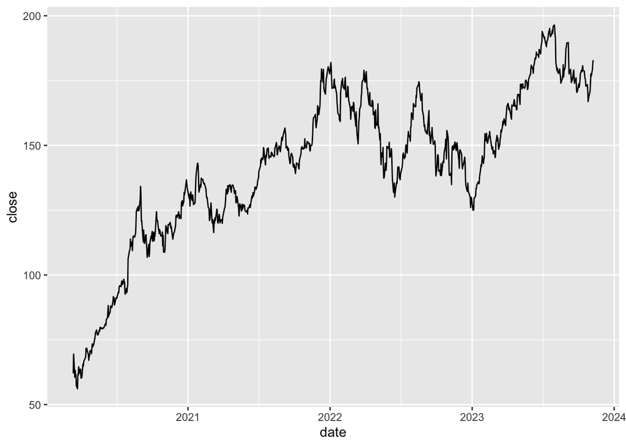

```r
company_data %>%
  ggplot(aes(x = date))+
  geom_line(aes(y = close))
```

### The loop of Understanding:

The visualisation offers a first glance We can transform again to ask the questions on the returns. We use the function `mutate()`, alongside `lag(0` to create a column with the daily (log) returns.

```r
company_data <- company_data %>%
  mutate(daily_log_returns = log(close)-log(lag(close)))
```

We can construct a visualisation with this. Additionally, we can add layers to our visualisation to decorate it at will.

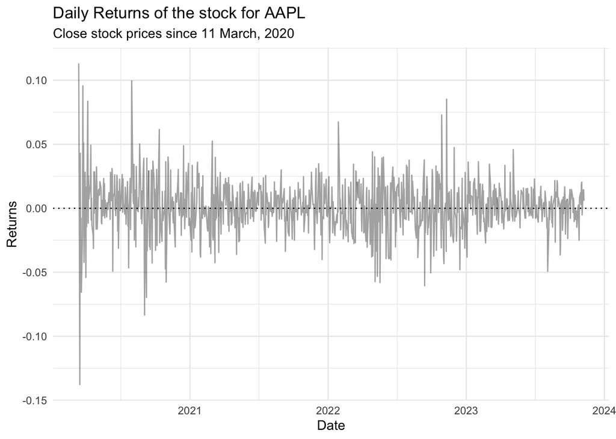

```r
company_data %>%
  ggplot(aes(x = date))+
  geom_line(aes(y = daily_log_returns), alpha = 0.5, color = "#555555") +
  geom_hline(yintercept = 0, lty = 3)+
  labs(
    title = str_glue("Daily Returns of the stock for {company_ticker}"),
    subtitle = str_glue("Close stock prices since {start_date %>% format('%d %B, %Y')}"),
    x = "Date",
    y = "Returns"
    ) +
  theme_minimal()
```

We can obtain a summary table for some summary statistics with `summarise()`

```r
company_data %>%
  summarise(`Average Return` = mean(daily_log_returns, na.rm = TRUE),
            `Average Risk (SD)` = sd(daily_log_returns, na.rm = TRUE))
```

```
## # A tibble: 1 × 2
##   `Average Return` `Average Risk (SD)`
##              <dbl>               <dbl>
## 1          0.00117              0.0206
```

And, seeing that the visualisation shows periods of high volatility in the year 2020, we can compute yearly measures of risk and volatility:

```r
company_data %>%
  mutate(year = year(date)) %>%
  group_by(year) %>%
  summarise(`Average Return` = mean(daily_log_returns, na.rm = TRUE),
            `Average Risk (SD)` = sd(daily_log_returns, na.rm = TRUE))
```

```
## # A tibble: 4 × 3
##    year `Average Return` `Average Risk (SD)`
##   <dbl>            <dbl>               <dbl>
## 1  2020          0.00373              0.0283
## 2  2021          0.00116              0.0158
## 3  2022         -0.00124              0.0224
## 4  2023          0.00159              0.0133
```

Ok we see that:

- Now things are more stable and **less uncertain**

# Analysis for multiple companies

```r
company_tickers <- c(
  "AAPL", "MSFT", "GOOG", "AMZN", "TSLA")
company_names <- c(
  "Apple", "Microsoft", "Alphabet (Google)", "Amazon", "Tesla")
company_colors <-  c("AAPL" = "#555555",
             "MSFT" = "#7FBA00",
             "GOOG" ="#4285F4" ,
             "AMZN" = "#FF9900",
             "TSLA" = "#cc0000"
             )
```

# Reading multiple data

```r
read_sheet <- function(sheet){
  read_xlsx(
    path = "data/stocks_data.xlsx",
    sheet = sheet)
}

library(purrr)

returns_data <-
  company_tickers %>%
  map(read_sheet) %>%
  bind_rows() %>%
  filter(date > start_date) %>%
  select(symbol,date, close) %>%
  group_by(symbol) %>%
  mutate(daily_log_returns = log(close) - log(lag(close))) %>%
  ungroup()
```

## Plotting the stock price

A single chart is not very satisfactory, even if we try to make differentiate companies with colors.

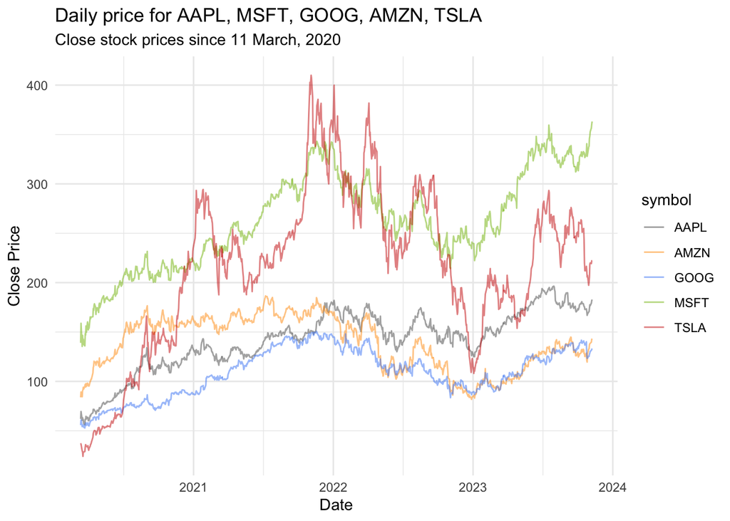

```r
returns_data %>%
  ggplot(aes(x = date, y = close,  group = symbol, color = symbol))+
  geom_line(alpha=0.5)+
  labs(
    title = str_glue("Daily price for {glue::glue_collapse(company_tickers, sep = ', ')}"),
    subtitle = str_glue("Close stock prices since {start_date %>% format('%d %B, %Y')}"),
    x = "Date",
    y = "Close Price"
    ) +
  theme_minimal()+
  scale_color_manual(values = company_colors)
```

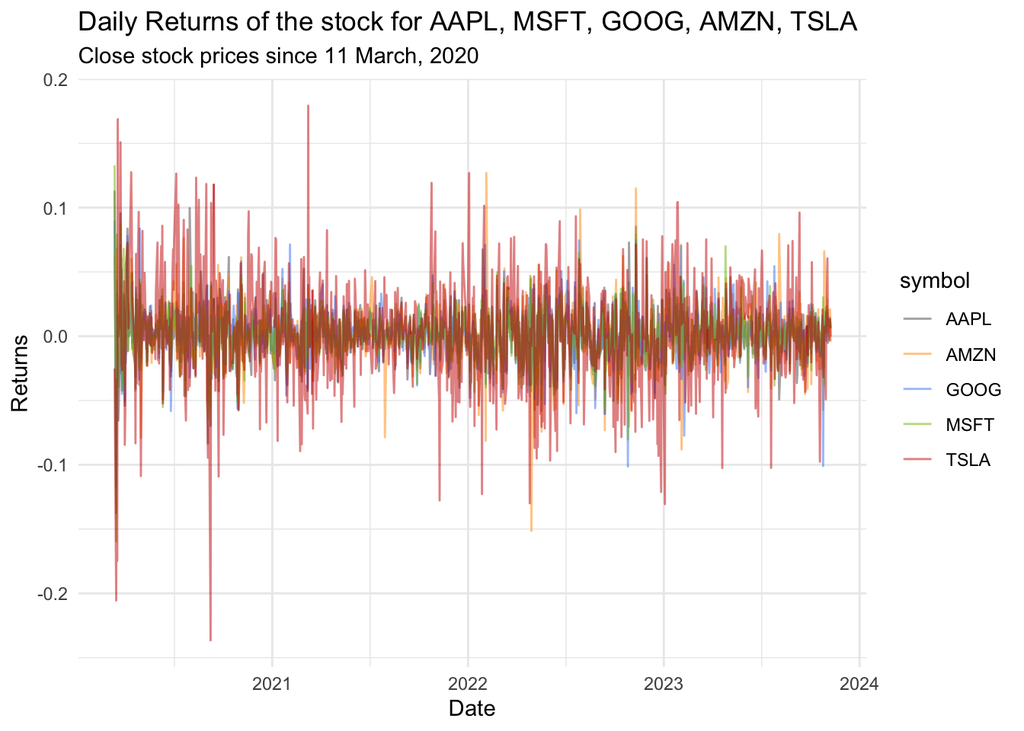

```r
returns_data %>%
  ggplot(aes(x = date, y = daily_log_returns,  group = symbol, color = symbol))+
  geom_line(alpha = 0.5) +
  labs(
    title = str_glue("Daily Returns of the stock for {glue::glue_collapse(company_tickers, sep = ', ')}"),
    subtitle = str_glue("Close stock prices since {start_date %>% format('%d %B, %Y')}"),
    x = "Date",
    y = "Returns"
    ) +
  theme_minimal()+
  # theme(legend.position = "none")+
  scale_color_manual(values = company_colors)
```

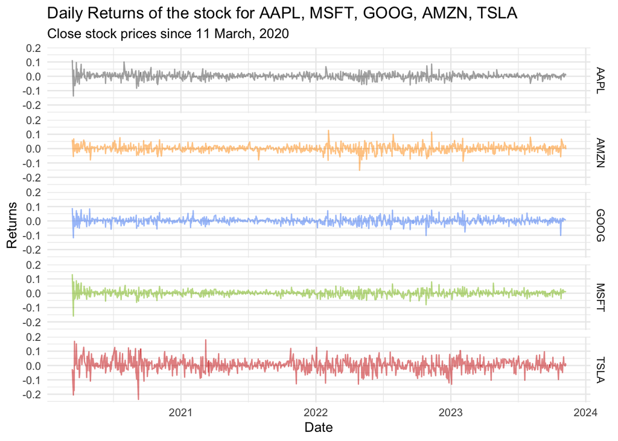

```r
returns_data %>%
  ggplot(aes(x = date, y = daily_log_returns,  group = symbol, color = symbol))+
  geom_line(alpha = 0.5) +
  labs(
    title = str_glue("Daily Returns of the stock for {glue::glue_collapse(company_tickers, sep = ', ')}"),
    subtitle = str_glue("Close stock prices since {start_date %>% format('%d %B, %Y')}"),
    x = "Date",
    y = "Returns"
    ) +
  theme_minimal()+
  facet_grid(rows = vars(symbol))+
  theme(legend.position = "none")+
  scale_color_manual(values = company_colors)
```

```r
mean_and_sd <-
  returns_data %>%
  mutate(year = year(date)) %>%
  group_by(symbol, year) %>%
  summarise(
    average_return = mean(daily_log_returns, na.rm = TRUE),
    sd_return = sd(daily_log_returns, na.rm = TRUE)
    )
mean_and_sd %>%
  select(-sd_return) %>%
  pivot_wider(names_from = year,values_from = average_return)
```

```
## # A tibble: 5 × 5
## # Groups:   symbol [5]
##   symbol  `2020`    `2021`   `2022`  `2023`
##   <chr>    <dbl>     <dbl>    <dbl>   <dbl>
## 1 AAPL   0.00373 0.00116   -0.00124 0.00159
## 2 AMZN   0.00325 0.0000932 -0.00273 0.00244
## 3 GOOG   0.00222 0.00199   -0.00195 0.00189
## 4 MSFT   0.00230 0.00164   -0.00135 0.00193
## 5 TSLA   0.00902 0.00160   -0.00419 0.00274
```

```r
mean_and_sd %>%
  select(-average_return) %>%
  pivot_wider(names_from = year,values_from = sd_return)
```

```
## # A tibble: 5 × 5
## # Groups:   symbol [5]
##   symbol `2020` `2021` `2022` `2023`
##   <chr>   <dbl>  <dbl>  <dbl>  <dbl>
## 1 AAPL   0.0283 0.0158 0.0224 0.0133
## 2 AMZN   0.0237 0.0152 0.0316 0.0218
## 3 GOOG   0.0234 0.0149 0.0244 0.0200
## 4 MSFT   0.0268 0.0132 0.0223 0.0164
## 5 TSLA   0.0538 0.0342 0.0423 0.0352
```